# SES 5215 | Analytic Methods of Urban Planning: Quantitative

Sai Joshi, Jialei Tang, Yuanzhao Wang

2021/10/22

```r
library(tidyverse)
library(sf)
library(knitr)
library(readxl)
library(gridExtra)
```

# Research Question

Does the environnment sustainability status of a city impact the wellbeing of its citizens?

# Citation articles

C. Yin & C. Shao. Revisiting commuting, built environment and happiness: New evidence on a nonlinear relationship, *Transportation Research Part D: Transport and Environment* Volume 100 (2021) https://doi.org/10.1016/j.trd.2021.103043.

Riffat, S., Powell, R. & Aydin, D. Future cities and environmental sustainability. *Fut Cit & Env 2, 1* (2016). https://doi.org/10.1186/s40984-016-0014-2

# Sample population

The cities of which data on wellbeing, emissions, energy mix, vulnerability assessment and could be obtained.

# Variables

## Categorical Variables (2)

- Vulnerability Assessment
- C40 Status

## Continuous Variables (4)

- Emissions
- Wellbeing index
- Population density
- Percentage of Energy Use from Renewable Sources

# Number of observations (rows) in our data set

```r
main <- st_read("values_variablesonly.xlsx")
total <- st_read("combinedmain_valuesonlyr.csv")
```

Number of Observations:

291 Observations (Rows/Cities)

We intend to collate further data to include in the event that the number of cities are insufficient for analysis.

```r
kable(head(total))
```

| Account.number | City | Country | Region | C40_Status | VA_Year | Cimate.change.risk.or.vulnerability.assessment.done. | EMCoal | EMGas | EMOil | EMNuclear | EMHydro | EMBiomass | EMWind | EMGeothermal | EMSolar | EMOther.sources | Percentage.Renewable | EmYear | EmYearReported | City.wide.emissions.inventory | EmissionsAccountingYear | Gases.Included | Direct.emissions..metric.tonnes.CO2e..for.Total.generation.of.grid.supplied.energy | Direct.emissions..metric.tonnes.CO2e..for.Total.emissions..excluding.generation.of.grid.supplied.energy. | Indirect.emissions.from.use.of.grid.supplied.energy..metric.tonnes.CO2e..for.Total.generation.of.grid.supplied.energy | Indirect.emissions.from.use.of.grid.supplied.energy..metric.tonnes.CO2e..for.Total.Emissions..excluding.generation.of.grid.supplied.energy. | Emissions.occurring.outside.city.boundary..metric.tonnes.CO2e..for.Total.Generation.of.grid.supplied.energy | Emissions.occurring.outside.city.boundary..metric.tonnes.CO2e..for.Total.Emissions..excluding.generation.of.grid.supplied.energy. | TotalEmissions | … |
| --- | --- | --- | --- | --- | --- | --- | --- | --- | --- | --- | --- | --- | --- | --- | --- | --- | --- | --- | --- | --- | --- | --- | --- | --- | --- | --- | --- | --- | --- | --- |
| 63999 | City of Miami Beach, FL | USA | North America |  | 2017 | In progress | 3.6 | 69.8 | 0.5 | 21.7 | 0 | 0 | 0 | 0 | 0.4 | 4 | 0.26 | 2017 | 2021 | Yes | 2019-01-01 - 2019-12-31 | CH4, CO2, N20 |  | 316878.7 |  | 729150 |  | 156635 | 1202663.7 | … |
| 36223 | Antananarivo | Madagascar | Africa |  | 2017 | In progress |  |  | 80 | 0 | 20 | 0 | 0 | 0 | 0 |  | 0.2 | 2019 | 2021 | Not intending to undertake |  |  |  |  |  |  |  |  | 0 | … |
| 8242 | City of Helsinki | Finland | Europe |  | 2017 | In progress | 7.5 | 5.9 | 0.3 | 34.7 | 18.6 | 18.1 | 9.1 | 0 | 0.3 | 5.5 | 0.86 | 2019 | 2021 | Yes | 2019-01-01 - 2019-12-31 | CH4, CO2, N20 | 3233000 | 824063 |  | 1785915 |  |  | 5842978 | … |
| 35885 | Tel Aviv-Yafo Municipality | Israel | South and West Asia |  | 2017 | Yes | 25 | 70 |  |  |  |  | 0.7 |  | 4.3 |  | 0.05 | 2019 | 2021 | Yes | 2017-01-01 - 2017-12-31 | CH4, CO2, N20 |  |  |  |  |  |  | 0 | … |
| 36039 | Accra Metropolitan Assembly | Ghana | Africa | C40 | 2017 | No |  |  |  |  |  |  |  |  |  |  | 0 |  | 2021 | Yes | 2015-01-01 - 2015-12-31 | CH4, CO2, N20 |  |  |  |  |  |  | 0 | … |
| 1499 | Ajuntament de Barcelona | Spain | Europe | C40 | 2017 | In progress | 0 | 24.38 | 0.25 | 44.39 | 11.36 | 0.16 | 5.73 | 0 | 0.97 | 12.76 | 0.75 | 2018 | 2021 | Yes | 2019-01-01 - 2019-12-31 | CH4, CO2, N20 | 1121894 | 1986025 |  | 795667 |  | 60247 | 3963833 | … |

```r
kable(head(main))
```

| Account.number | City | Region | X.Population | PopYear | Location | C40_Status | Vadone | Vacommenced | PercentageRenewable | PercentRenew | PopulationDensity | TotalEmissions | WellBeing |
| --- | --- | --- | --- | --- | --- | --- | --- | --- | --- | --- | --- | --- | --- |
| 63999 | City of Miami Beach, FL | USA | 91826 | 2018 | POINT (-80.13 25.7906) | No | In progress | Yes | 0.26 | 26 | 5064.86 | 1202664 | 7.028 |
| 8242 | City of Helsinki | Finland | 655395 | 2020 | POINT (24.941 60.1733) | No | In progress | Yes | 0.86 | 86 | 3059.02 | 5842978 | 7.828 |
| 35885 | Tel Aviv-Yafo Municipality | Israel | 460600 | 2019 | POINT (34.7823 32.0816) | No | Yes | Yes | 0.05 | 5 | 8857.69 | 5296900 | 7.461 |
| 36039 | Accra Metropolitan Assembly | Ghana | 2514005 | 2020 | POINT (-0.16819 5.56543) | C40 | No | No | 0.00 | 0 | 47527.32 | 2715125 | 5.267 |
| 1499 | Ajuntament de Barcelona | Spain | 1664182 | 2020 | POINT (2.1775 41.3823) | C40 | In progress | Yes | 0.75 | 75 | 16291.55 | 3963833 | 6.380 |
| 35860 | City of Dallas | USA | 1345047 | 2018 | POINT (-96.8004 32.7801) | No | No | No | 0.33 | 33 | 1349.09 | 22193276 | 7.155 |

# Reading our data

## Our continuous variables are:

- Emissions
- Wellbeing index
- Population density
- Energy Mix (Source of electricity)

```r
data <- read_xlsx(path = "values_variablesonly.xlsx",
                      sheet = "Sheet1") %>%
  mutate(log_emissions = log(TotalEmissions))
energy_t_test <- t.test(data$PercentRenew)
dens_t_test <- t.test(data$PopulationDensity)
emission_t_test <- t.test(data$TotalEmissions)
wellbeing_t_test <- t.test(data$WellBeing)
```

```r
energy_quartiles <- quantile(data$PercentRenew, na.rm = TRUE)
dens_quartiles <- quantile(data$PopulationDensity, na.rm = TRUE)
emission_quartiles <- quantile(data$TotalEmissions, na.rm = TRUE)
wellbeing_quartiles <- quantile(data$WellBeing, na.rm = TRUE)

energy_dev <- sd(data$PercentRenew, na.rm = TRUE)
dens_dev <- sd(data$PopulationDensity, na.rm = TRUE)
emission_dev <- sd(data$TotalEmissions, na.rm = TRUE)
wellbeing_dev <- sd(data$WellBeing, na.rm = TRUE)

energy_hist <- ggplot(data) +
  geom_histogram(aes(x = PercentRenew),
                 bins = 30)

dens_hist <- ggplot(data) +
  geom_histogram(aes(x = PopulationDensity),
                 bins = 30) +
  scale_x_continuous(trans = "log")

emission_hist <- ggplot(data) +
  geom_histogram(aes(x = log_emissions),
                 bins = 30)

wellbeing_hist <- ggplot(data) +
  geom_histogram(aes(x = WellBeing),
                 bins = 30)
```

```r
cont_summary <- tibble(`Variable` = c("Percentage of Energy Use from Renewable Sources",
               "Population density (people per square kilometers)",
               "Total Emissions (metric tonnes CO2e)",
               "WellBeing scores"),

`Sample mean` = c(energy_t_test$estimate,
                    dens_t_test$estimate,
                    emission_t_test$estimate,
                    wellbeing_t_test$estimate* 1000),

`Population mean (95% confidence) - low` =
    c(energy_t_test$conf.int[1],
      dens_t_test$conf.int[1],
      emission_t_test$conf.int[1],
      wellbeing_t_test$conf.int[1]* 1000),
`Population mean (95% confidence) - high` =
    c(energy_t_test$conf.int[2],
      dens_t_test$conf.int[2],
      emission_t_test$conf.int[2],
      wellbeing_t_test$conf.int[2] * 1000),
`Median` = c(energy_quartiles[3],
             dens_quartiles[3],
             emission_quartiles[3],
             wellbeing_quartiles[3] * 1000),
`Interquartile range` = c(energy_quartiles[4] - energy_quartiles[2],
                            dens_quartiles[4] - dens_quartiles[2],
                            emission_quartiles[4] - emission_quartiles[2],
                            wellbeing_quartiles[4] - wellbeing_quartiles[2]* 1000),
`Standard deviation` = c(energy_dev,
                          dens_dev,
                          emission_dev,
                          wellbeing_dev* 1000))

kable(cont_summary, digits = 0)
```

| Variable | Sample mean | Population mean (95% confidence) - low | Population mean (95% confidence) - high | Median | Interquartile range | Standard deviation |
| --- | --- | --- | --- | --- | --- | --- |
| Percentage of Energy Use from Renewable Sources | 42 | 33 | 52 | 40 | 55 | 32 |
| Population density (people per square kilometers) | 7668 | 4548 | 10787 | 4750 | 3918 | 10383 |
| Total Emissions (metric tonnes CO2e) | 23124397 | 12561355 | 33687440 | 6192461 | 24910479 | 35159364 |
| WellBeing scores | 6546 | 6317 | 6775 | 6650 | -6021 | 762 |

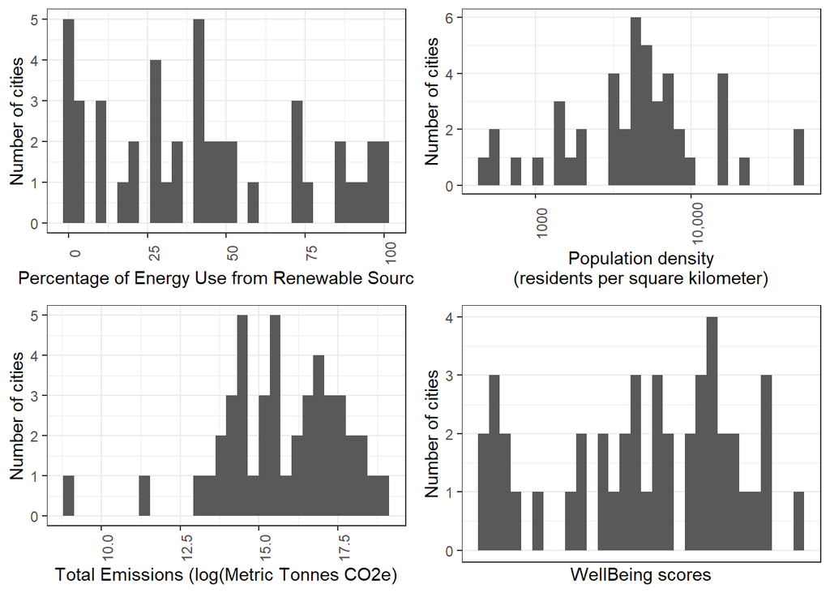

```r
pretty_energy_hist <- energy_hist +
  theme_bw() +
  scale_x_continuous(name = "Percentage of Energy Use from Renewable Sources") +
  scale_y_continuous(name = "Number of cities") +
  theme(axis.text.x = element_text(angle = 90))

pretty_dens_hist <- dens_hist +
  theme_bw() +
  scale_x_continuous(name = "Population density\n(residents per square kilometer)",
                     trans = "log",
                     breaks = c(0.1, 1, 10, 100, 1000, 10000),
                     labels = c("0.1", "1", "10", "100", "1000", "10,000")) +
  scale_y_continuous(name = "Number of cities") +
  theme(axis.text.x = element_text(angle = 90))

pretty_emission_hist = emission_hist +
  theme_bw() +
  scale_x_continuous(name = "Total Emissions (log(Metric Tonnes CO2e)") +
  scale_y_continuous(name = "Number of cities") +
  theme(axis.text.x = element_text(angle = 90))

pretty_wellbeing_hist = wellbeing_hist +
  theme_bw() +
  scale_x_continuous(name = "WellBeing scores",
                     breaks = seq(0, 0.3, by=.05),
                     labels = seq(0, 300, by = 50)) +
  scale_y_continuous(name = "Number of cities") +
  theme(axis.text.x = element_text(angle = 90))

grid.arrange(pretty_energy_hist, pretty_dens_hist, pretty_emission_hist, pretty_wellbeing_hist,
             ncol = 2, nrow = 2)
```

# Sample Proportion for each Category

## Our categorical variables are:

- Vulnerability Assessment
- C40 Status

```r
pct_C40 <- t.test(main$C40_Status == "C40")
pct_nonC40 <- t.test(main$C40_Status == "No")
```

```r
cat_summary_C40 <- tibble(`C40 Cities` =
                              c("C40",
                                "Non C40"),
                            `Sample proportion` =
                              c(pct_C40$estimate * 100,
                                pct_nonC40$estimate *100),
                            `95-percent confidence - low` =
                              c(pct_C40$conf.int[1] * 100,
                                pct_nonC40$conf.int[1] * 100),
                            `95-percent confidence - high` =
                              c(pct_C40$conf.int[2] * 100,
                                pct_nonC40$conf.int[2] * 100))

kable(cat_summary_C40, digits = 0)
```

| C40 Cities | Sample proportion | 95-percent confidence - low | 95-percent confidence - high |
| --- | --- | --- | --- |
| C40 | 71 | 57 | 85 |
| Non C40 | 29 | 15 | 43 |

# The 95-percent confidence interval for the population proportion in each category

```r
pct_VAdone <- t.test(main$Vadone == "Yes")
pct_VAinprogress <- t.test(main$Vadone == "In progress")
pct_VAno <-  t.test(main$Vadone == "No")
```

```r
cat_summary_VAdone <- tibble(`Conducted Vulnerability Assessment?` =
                              c("Yes",
                                "In Progress",
                                "No"),
                            `Sample proportion` =
                              c(pct_VAdone$estimate * 100,
                                pct_VAinprogress$estimate * 100,
                                pct_VAno$estimate * 100),
                            `95-percent confidence - low` =
                              c(pct_VAdone$estimate * 100,
                                pct_VAinprogress$estimate * 100,
                                pct_VAno$estimate * 100),
                            `95-percent confidence - high` =
                              c(pct_VAdone$conf.int[2] * 100,
                                pct_VAinprogress$conf.int[2] * 100,
                                pct_VAno$conf.int[2] * 100))

kable(cat_summary_VAdone, digits = 0)
```

| Conducted Vulnerability Assessment? | Sample proportion | 95-percent confidence - low | 95-percent confidence - high |
| --- | --- | --- | --- |
| Yes | 69 | 69 | 83 |
| In Progress | 18 | 18 | 29 |
| No | 13 | 13 | 24 |

# Bivariate analysis

## Correlations / regression on continuous variables

Well-being is our key variable. The components of the well-being index are

- Annual hours of sunshine hours
- Access to green space
- Crime
- Traffic congstion
- Happiness
- Quality of healthcare
- Work-life Balance
- Governance

We recognize the limitations of this index and remain critical of its representation of the quality of life of citizens in the cities examined. Nevertheless, it is an interesting study and we are curious if the continuous and categorical variables we’ve identified can give the index more context as we establish its relationships to these variables.

In this exercise, we would like to investigate the correlations between

- wellbeing and emissions
- wellbeing and population density
- wellbeing and energy-mix
- population and emissions
- emissions and energy-mix

## Correlation wellbeing and emissions

The p-value is more than 0.05 at 0.3891, which means the relationship is insignificant. This is also clear from the fact that the entire 95-percent confidence interval is both positive and negative, which suggests that the relationship is neither inverse or direct.

```r
cor.test(~ WellBeing + TotalEmissions, data = main)
```

```
##
##  Pearson's product-moment correlation
##
## data:  WellBeing and TotalEmissions
## t = -0.87008, df = 43, p-value = 0.3891
## alternative hypothesis: true correlation is not equal to 0
## 95 percent confidence interval:
##  -0.4092657  0.1685066
## sample estimates:
##        cor
## -0.1315333
```

```r
wb_emissions_model <- lm(WellBeing ~ TotalEmissions, data = main)

summary(wb_emissions_model)
```

```
##
## Call:
## lm(formula = WellBeing ~ TotalEmissions, data = main)
##
## Residuals:
##     Min      1Q  Median      3Q     Max
## -1.4445 -0.4285  0.2117  0.5932  1.2328
##
## Coefficients:
##                  Estimate Std. Error t value Pr(>|t|)
## (Intercept)     6.612e+00  1.369e-01   48.30   <2e-16 ***
## TotalEmissions -2.852e-09  3.278e-09   -0.87    0.389
## ---
## Signif. codes:  0 '***' 0.001 '**' 0.01 '*' 0.05 '.' 0.1 ' ' 1
##
## Residual standard error: 0.7646 on 43 degrees of freedom
## Multiple R-squared:  0.0173, Adjusted R-squared:  -0.005552
## F-statistic: 0.757 on 1 and 43 DF,  p-value: 0.3891
```

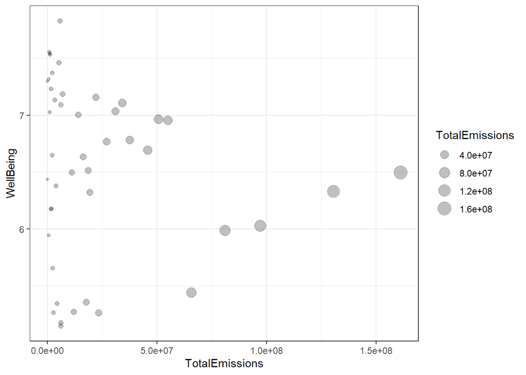

```r
ggplot(main) +
  geom_point(aes(x = TotalEmissions,
                 y = WellBeing,
                 size = TotalEmissions),
             alpha = 0.25) +
  theme_bw()
```

## Correlation wellbeing and population density

The p-value is more than 0.05 at 0.3906, which means the relationship is insignificant. This is also clear from the fact that the entire 95-percent confidence interval is both positive and negative, which suggests that the relationship is neither inverse or direct.

```r
cor.test(~ WellBeing + PopulationDensity, data = main)
```

```
##
##  Pearson's product-moment correlation
##
## data:  WellBeing and PopulationDensity
## t = -0.86728, df = 43, p-value = 0.3906
## alternative hypothesis: true correlation is not equal to 0
## 95 percent confidence interval:
##  -0.4089131  0.1689179
## sample estimates:
##        cor
## -0.1311172
```

```r
wb_popdens_model <- lm(WellBeing ~ PopulationDensity, data = main)

summary(wb_popdens_model)
```

```
##
## Call:
## lm(formula = WellBeing ~ PopulationDensity, data = main)
##
## Residuals:
##     Min      1Q  Median      3Q     Max
## -1.4108 -0.5151  0.1318  0.5482  1.2584
##
## Coefficients:
##                     Estimate Std. Error t value Pr(>|t|)
## (Intercept)        6.620e+00  1.423e-01  46.532   <2e-16 ***
## PopulationDensity -9.628e-06  1.110e-05  -0.867    0.391
## ---
## Signif. codes:  0 '***' 0.001 '**' 0.01 '*' 0.05 '.' 0.1 ' ' 1
##
## Residual standard error: 0.7646 on 43 degrees of freedom
## Multiple R-squared:  0.01719,    Adjusted R-squared:  -0.005664
## F-statistic: 0.7522 on 1 and 43 DF,  p-value: 0.3906
```

## Correlation/Regression wellbeing and energy mix

The p-value is less than 0.05 at 0.000009851, which means the relationship is significant. This is also clear from the fact that the entire 95-percent confidence interval is positive, which suggests that the relationship is direct.

This result is interesting and it could be suggesting that cleaner cities provide better conditions for a higher wellbeing.

```r
cor.test(~ WellBeing + PercentRenew, data = main)
```

```
##
##  Pearson's product-moment correlation
##
## data:  WellBeing and PercentRenew
## t = 5.0083, df = 43, p-value = 9.851e-06
## alternative hypothesis: true correlation is not equal to 0
## 95 percent confidence interval:
##  0.3813948 0.7643308
## sample estimates:
##       cor
## 0.6069763
```

```r
wb_energy_model <- lm(WellBeing ~ PercentRenew, data = main)

summary(wb_energy_model)
```

```
##
## Call:
## lm(formula = WellBeing ~ PercentRenew, data = main)
##
## Residuals:
##      Min       1Q   Median       3Q      Max
## -1.03720 -0.58602  0.08067  0.44769  1.45596
##
## Coefficients:
##              Estimate Std. Error t value Pr(>|t|)
## (Intercept)  5.932512   0.152812  38.822  < 2e-16 ***
## PercentRenew 0.014506   0.002896   5.008 9.85e-06 ***
## ---
## Signif. codes:  0 '***' 0.001 '**' 0.01 '*' 0.05 '.' 0.1 ' ' 1
##
## Residual standard error: 0.6129 on 43 degrees of freedom
## Multiple R-squared:  0.3684, Adjusted R-squared:  0.3537
## F-statistic: 25.08 on 1 and 43 DF,  p-value: 9.851e-06
```

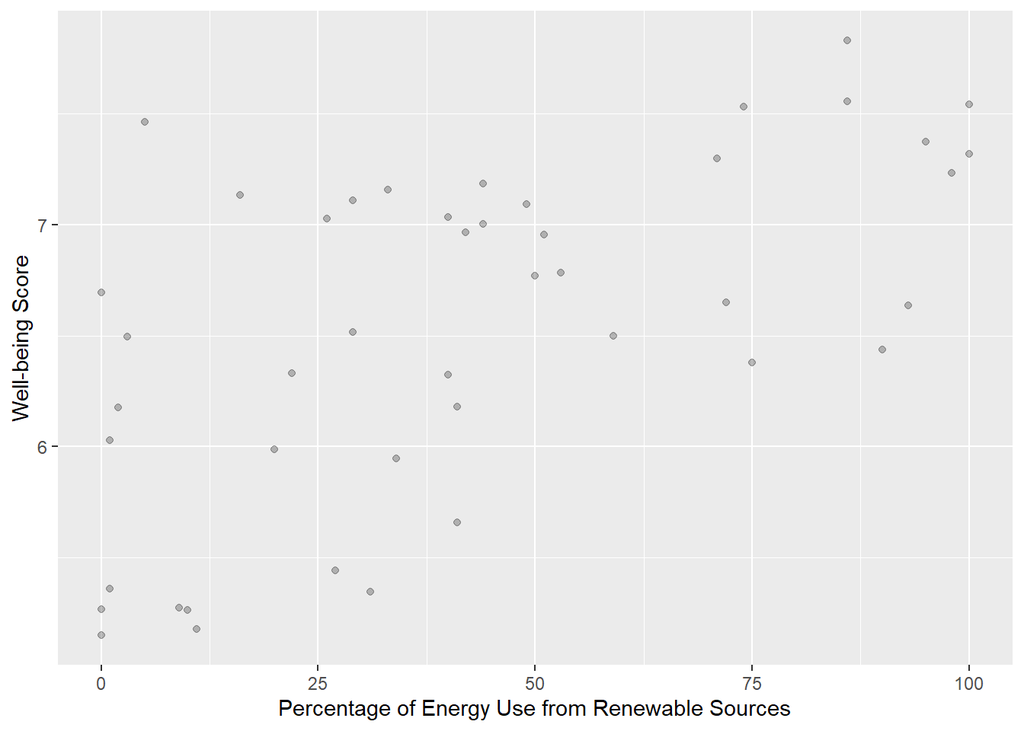

```r
ggplot(main) +
  geom_point(aes(x = PercentRenew,
                 y = WellBeing),
             alpha = 0.25) +
  labs(y="Well-being Score", x = "Percentage of Energy Use from Renewable Sources")
```

```r
  theme_bw()
```

[output not shown]

[output cut: 365 more lines]

[output not shown]

## Correlation population density and emissions

The p-value is more than 0.05 at 0.4849, which means the relationship is insignificant. This is also clear from the fact that the entire 95-percent confidence interval is both positive and negative, which suggests that the relationship is neither inverse or direct.

```r
cor.test(~ PopulationDensity + TotalEmissions, data = main)
```

```
##
##  Pearson's product-moment correlation
##
## data:  PopulationDensity and TotalEmissions
## t = -0.70459, df = 43, p-value = 0.4849
## alternative hypothesis: true correlation is not equal to 0
## 95 percent confidence interval:
##  -0.3881949  0.1927437
## sample estimates:
##        cor
## -0.1068346
```

```r
popdens_te_model <- lm(PopulationDensity ~ TotalEmissions, data = main)

summary(popdens_te_model)
```

```
##
## Call:
## lm(formula = PopulationDensity ~ TotalEmissions, data = main)
##
## Residuals:
##    Min     1Q Median     3Q    Max
##  -7894  -5198  -3271    524  44135
##
## Coefficients:
##                  Estimate Std. Error t value Pr(>|t|)
## (Intercept)     8.397e+03  1.870e+03   4.491 5.25e-05 ***
## TotalEmissions -3.155e-05  4.478e-05  -0.705    0.485
## ---
## Signif. codes:  0 '***' 0.001 '**' 0.01 '*' 0.05 '.' 0.1 ' ' 1
##
## Residual standard error: 10440 on 43 degrees of freedom
## Multiple R-squared:  0.01141,    Adjusted R-squared:  -0.01158
## F-statistic: 0.4965 on 1 and 43 DF,  p-value: 0.4849
```

## Correlation emissions and energy mix

The p-value is less than 0.05 at 0.0105, which means the relationship is significant. This is also clear from the fact that the entire 95-percent confidence interval is negative (it does not include zero), which suggests that the relationship is inverse.

```r
cor.test(~ TotalEmissions + PercentageRenewable, data = data)
```

```
##
##  Pearson's product-moment correlation
##
## data:  TotalEmissions and PercentageRenewable
## t = -2.6759, df = 43, p-value = 0.0105
## alternative hypothesis: true correlation is not equal to 0
## 95 percent confidence interval:
##  -0.6043381 -0.0948096
## sample estimates:
##        cor
## -0.3778286
```

```r
te_energy_model <- lm(TotalEmissions ~ PercentageRenewable, data = main)

summary(te_energy_model)
```

```
##
## Call:
## lm(formula = TotalEmissions ~ PercentageRenewable, data = main)
##
## Residuals:
##       Min        1Q    Median        3Q       Max
## -38330072 -21772038  -5060430   5396872 121754312
##
## Coefficients:
##                      Estimate Std. Error t value Pr(>|t|)
## (Intercept)          40732842    8209561   4.962 1.15e-05 ***
## PercentageRenewable -41638465   15560311  -2.676   0.0105 *
## ---
## Signif. codes:  0 '***' 0.001 '**' 0.01 '*' 0.05 '.' 0.1 ' ' 1
##
## Residual standard error: 32930000 on 43 degrees of freedom
## Multiple R-squared:  0.1428, Adjusted R-squared:  0.1228
## F-statistic: 7.161 on 1 and 43 DF,  p-value: 0.0105
```

# Difference in means / regression on categorical variables

## Difference in means on wellbeing and c40 status

The p-value is more than 0.05 at 0.2037, which means the relationship is insignificant. This is also clear from the fact that the entire 95-percent confidence interval is both positive and negative, which suggests that the relationship is neither inverse or direct.

```r
t.test(WellBeing ~ C40_Status, main)
```

```
##
##  Welch Two Sample t-test
##
## data:  WellBeing by C40_Status
## t = -1.3131, df = 20.452, p-value = 0.2037
## alternative hypothesis: true difference in means between group C40 and group No is not equal to 0
## 95 percent confidence interval:
##  -0.8800572  0.1995235
## sample estimates:
## mean in group C40  mean in group No
##          6.447656          6.787923
```

```r
wb_c40_model <- lm(WellBeing ~ C40_Status, data = main)

summary(wb_c40_model)
```

```
##
## Call:
## lm(formula = WellBeing ~ C40_Status, data = main)
##
## Residuals:
##     Min      1Q  Median      3Q     Max
## -1.6079 -0.5007  0.1873  0.6433  1.0823
##
## Coefficients:
##              Estimate Std. Error t value Pr(>|t|)
## (Intercept)    6.4477     0.1335   48.31   <2e-16 ***
## C40_StatusNo   0.3403     0.2483    1.37    0.178
## ---
## Signif. codes:  0 '***' 0.001 '**' 0.01 '*' 0.05 '.' 0.1 ' ' 1
##
## Residual standard error: 0.755 on 43 degrees of freedom
## Multiple R-squared:  0.04184,    Adjusted R-squared:  0.01956
## F-statistic: 1.878 on 1 and 43 DF,  p-value: 0.1777
```

## Difference in means on wellbeing and status of vulnerability assessment (done or not)

```r
t.test(WellBeing ~ Vacommenced, data = main)
```

```
##
##  Welch Two Sample t-test
##
## data:  WellBeing by Vacommenced
## t = -2.2926, df = 6.3158, p-value = 0.05957
## alternative hypothesis: true difference in means between group No and group Yes is not equal to 0
## 95 percent confidence interval:
##  -1.61071134  0.04273698
## sample estimates:
##  mean in group No mean in group Yes
##          5.866500          6.650487
```

```r
wb_va_model <- lm(WellBeing ~ Vadone, data = main)

summary(wb_va_model)
```

```
##
## Call:
## lm(formula = WellBeing ~ Vadone, data = main)
##
## Residuals:
##     Min      1Q  Median      3Q     Max
## -1.4025 -0.5915  0.1105  0.5085  1.2885
##
## Coefficients:
##             Estimate Std. Error t value Pr(>|t|)
## (Intercept)   6.9140     0.2540  27.216  < 2e-16 ***
## VadoneNo     -1.0475     0.3881  -2.699  0.00997 **
## VadoneYes    -0.3315     0.2849  -1.163  0.25121
## ---
## Signif. codes:  0 '***' 0.001 '**' 0.01 '*' 0.05 '.' 0.1 ' ' 1
##
## Residual standard error: 0.7185 on 42 degrees of freedom
## Multiple R-squared:  0.1523, Adjusted R-squared:  0.1119
## F-statistic: 3.772 on 2 and 42 DF,  p-value: 0.03115
```